# Final Project–Regression

Xin Wang

December 7, 2016

### Step 1: Identify a good research question

Proposed Hypothesis: G3(dependent variable) is affected by some or all other independent variables in the data set

Why G3:

1. G3 is the final grade, it is less sensitive on data collection timing issue than G1 and G2, since some of the data could be collected after G1, G2, complicating the casual effect. Choosing G3 as dependent variable can mitigate the problem, since the variables with potential timing problems would be independent from other possible dependent variables (such as G1 or G2) in that case.
2. G3 is close to normal distribution (except some outliers) which is ideal for regression analysis.

### Step 2: Identify the data that help answer that question

Math and Language data sets

1. run regression on Math data
2. run classification on Language data

### Step 3: Obtain and read in data

### Step 4: Clean the data. Use the proper delimit, dealing with the missing data, treat the incorrect data class/type.

```r
# Set working directory
setwd("C:/Users/admin/Downloads/R projects/Final Project")
require(readr)
require(ISLR)
```

```r
require(ggplot2)
require(GGally)
require(caret)
require(MASS)
require(klaR)
require(glmnet)
require(class)
require(earth)
```

Read in data

```r
MathData <- read_delim("sm.csv", delim = ";")
# test if has missing data
table(is.na(MathData))
```

```
##
## FALSE
## 13035
```

```r
MathData <- as.data.frame(MathData)
# no missing value
```

### Step 5: Get to know the data with summarize and visualization tools

```r
attach(MathData)

summary(MathData)
```

```
##     school              sex                 age         address
##  Length:395         Length:395         Min.   :15.0   Length:395
##  Class :character   Class :character   1st Qu.:16.0   Class :character
##  Mode  :character   Mode  :character   Median :17.0   Mode  :character
##                                        Mean   :16.7
##                                        3rd Qu.:18.0
##                                        Max.   :22.0
##    famsize            Pstatus               Medu            Fedu
##  Length:395         Length:395         Min.   :0.000   Min.   :0.000
##  Class :character   Class :character   1st Qu.:2.000   1st Qu.:2.000
##  Mode  :character   Mode  :character   Median :3.000   Median :2.000
##                                        Mean   :2.749   Mean   :2.522
##                                        3rd Qu.:4.000   3rd Qu.:3.000
##                                        Max.   :4.000   Max.   :4.000
##      Mjob               Fjob              reason
##  Length:395         Length:395         Length:395
##  Class :character   Class :character   Class :character
##  Mode  :character   Mode  :character   Mode  :character
##
##
##
##    guardian           traveltime      studytime        failures
##  Length:395         Min.   :1.000   Min.   :1.000   Min.   :0.0000
##  Class :character   1st Qu.:1.000   1st Qu.:1.000   1st Qu.:0.0000
##  Mode  :character   Median :1.000   Median :2.000   Median :0.0000
##                     Mean   :1.448   Mean   :2.035   Mean   :0.3342
##                     3rd Qu.:2.000   3rd Qu.:2.000   3rd Qu.:0.0000
##                     Max.   :4.000   Max.   :4.000   Max.   :3.0000
##   schoolsup            famsup              paid
##  Length:395         Length:395         Length:395
##  Class :character   Class :character   Class :character
##  Mode  :character   Mode  :character   Mode  :character
##
##
##
##   activities          nursery             higher
##  Length:395         Length:395         Length:395
##  Class :character   Class :character   Class :character
##  Mode  :character   Mode  :character   Mode  :character
##
```

[output cut: 8 more lines]

```
##                                        Max.   :5.000   Max.   :5.000
##      goout            Dalc            Walc           health
##  Min.   :1.000   Min.   :1.000   Min.   :1.000   Min.   :1.000
##  1st Qu.:2.000   1st Qu.:1.000   1st Qu.:1.000   1st Qu.:3.000
##  Median :3.000   Median :1.000   Median :2.000   Median :4.000
##  Mean   :3.109   Mean   :1.481   Mean   :2.291   Mean   :3.554
##  3rd Qu.:4.000   3rd Qu.:2.000   3rd Qu.:3.000   3rd Qu.:5.000
##  Max.   :5.000   Max.   :5.000   Max.   :5.000   Max.   :5.000
##     absences            G1              G2              G3
##  Min.   : 0.000   Min.   : 3.00   Min.   : 0.00   Min.   : 0.00
##  1st Qu.: 0.000   1st Qu.: 8.00   1st Qu.: 9.00   1st Qu.: 8.00
##  Median : 4.000   Median :11.00   Median :11.00   Median :11.00
##  Mean   : 5.709   Mean   :10.91   Mean   :10.71   Mean   :10.42
##  3rd Qu.: 8.000   3rd Qu.:13.00   3rd Qu.:13.00   3rd Qu.:14.00
##  Max.   :75.000   Max.   :19.00   Max.   :19.00   Max.   :20.00
```

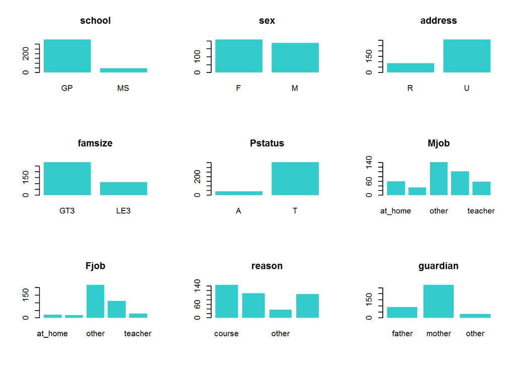

```r
charName <- names(MathData) %in% c("school", "sex", "address", "famsize", "Pstatus", "Mjob", "Fjob", "reason", "guardian", "schoolsup", "famsup", "paid", "activities", "nursery", "higher", "internet", "romantic")
charData <- MathData[charName]
numData <- MathData[!charName]

# plots for Character Variables
mainnames <- names(charData)
par(mfrow=c(3, 3))
for (i in 1:9){
    barplot(table(charData[,i]), main=mainnames[i], col = "#33cccc", border = NA)
}
```

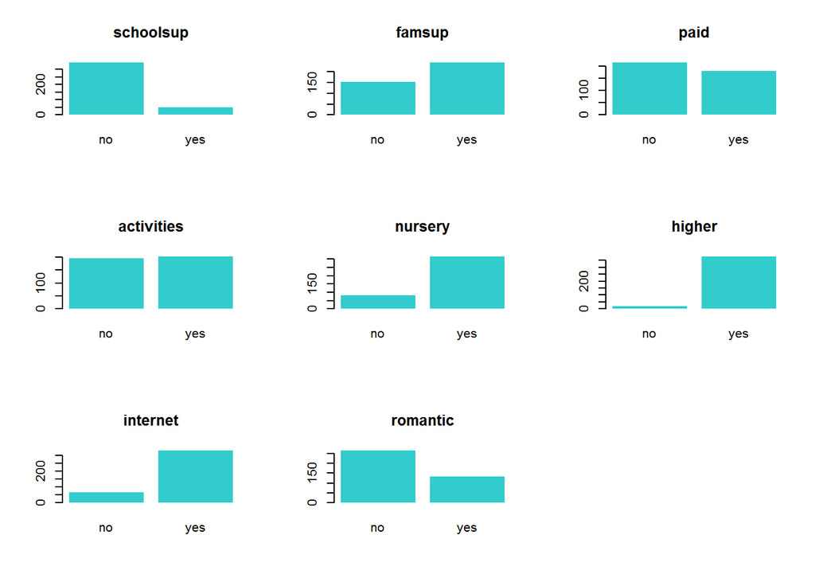

```r
par(mfrow=c(3, 3))
for (i in 10:17){
    barplot(table(charData[,i]), main=mainnames[i], col = "#33cccc", border = NA)
}

# plots for Numeric Variables
mainnames1 <- names(numData)
par(mfrow=c(3, 3))
```

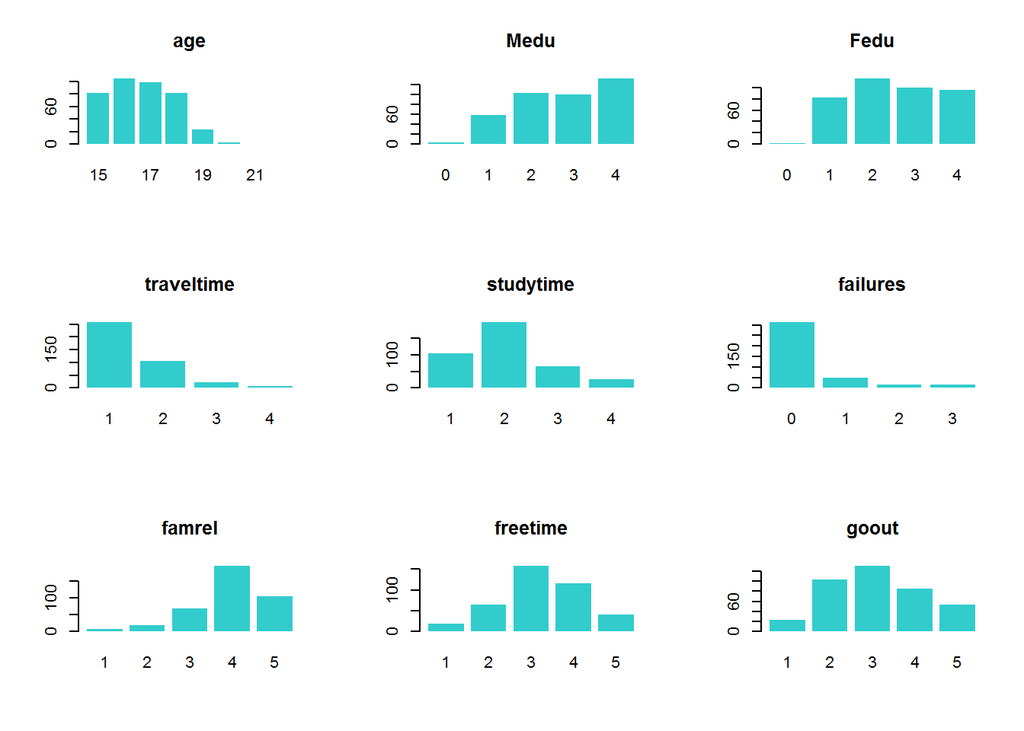

```r
for (i in 1:9){
    barplot(table(numData[,i]), main=mainnames1[i], col = "#33cccc", border = NA)
}
```

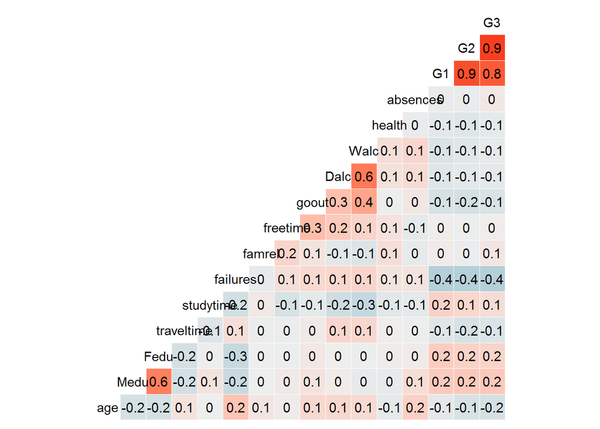

```r
par(mfrow=c(3, 3))
for (i in 10:16){
    barplot(table(numData[,i]), main=mainnames1[i], col = "#33cccc", border = NA)
}

# correlation
ggcorr(numData, label = TRUE, legend.position = "none")
```

[output not shown]

### Step 6: Treat Existing variables / Create new variables

Treat G1, G2, G3

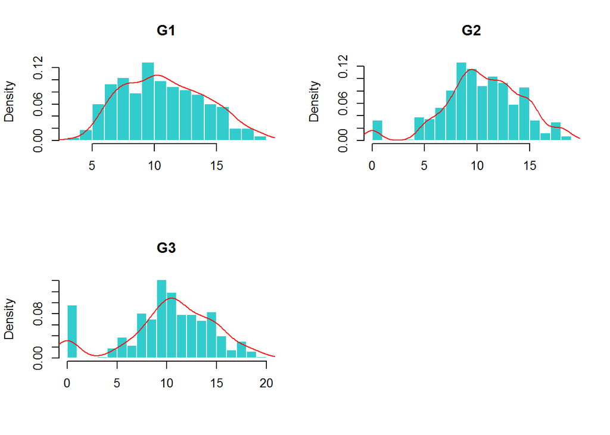

```r
# compare G1, G2, G3
G123 <- data.frame(G1=numData$G1, G2=numData$G2, G3=numData$G3)
par(mfrow=c(2, 2))
for (i in 1:3) {
    hist(G123[,i], main=names(G123)[i], probability=TRUE, breaks=20, col="#33cccc", border="white", xlab=NA)
    d <- density(G123[,i])
    lines(d, col="red")
}
# G3 is likely to be harder than G2 and G1 since the skewness shift towards left(lower grades) from G1, G2 to G3.
# there are also many 0 scores indicating they might be outliers.

# inspect the data to see if those scored 0 also scored low on G1, G2
inspect0score <- subset(numData, subset = G3==0, select = c(G1, G2, G3, absences, studytime))
par(mfrow=c(2, 3))
```

```r
for (i in 1:5) {
    barplot(table(inspect0score[,i]), main=names(inspect0score)[i], col="#33cccc", border=NA, xlab=NA)
}
mean(inspect0score$studytime)
```

```
## [1] 1.973684
```

```r
# those students have 0 absence
# they score relatively low on G1, too many of them scored 0 on G2
# their average study time is around level 2

# check if those scored 0 on both G2 and G3 study less time
lapply(subset(numData, subset = G3==0 & G2==0, select = c(G1, G2, G3, absences, studytime)),
       function(x) mean(x))
```

```
## $G1
## [1] 7.461538
##
## $G2
## [1] 0
##
## $G3
## [1] 0
##
## $absences
## [1] 0
##
## $studytime
## [1] 1.769231
```

```r
# these student did not score too low on G1 and their average study time is fair
# therefore, it is possible that they missed the exams, it may be helpful if remove these outliers

# remove potential outliers
MathData <- subset(numData, subset = !(G3==0 & G2==0))
```

[figure not shown]

Treat Alcohol Consumption variables

```r
# since Dalc and Walc are highly correlated and Dalc is quite skewed and they both describe the same thing,
# combine them into one varible
Math <- subset(MathData, select = -c(Dalc, Walc))
Math$Alc <- MathData$Dalc + MathData$Walc
```

### Step 7: Develop a modeling plan: which algorithms would be more likely to produce ideal results

preliminary correlation testing on different predictor combinations

```r
# 1
summary(lm(formula = G3 ~ ., data = Math))
```

```
##
## Call:
## lm(formula = G3 ~ ., data = Math)
##
## Residuals:
##     Min      1Q  Median      3Q     Max
## -8.7527 -0.4694  0.2966  0.9776  4.2195
##
## Coefficients:
##              Estimate Std. Error t value Pr(>|t|)
## (Intercept) -1.008464   1.623116  -0.621 0.534779
## age         -0.171182   0.085677  -1.998 0.046457 *
## Medu         0.062297   0.117533   0.530 0.596403
## Fedu        -0.123726   0.117740  -1.051 0.294020
## traveltime   0.135306   0.148212   0.913 0.361885
## studytime   -0.126173   0.124065  -1.017 0.309827
## failures    -0.279242   0.155074  -1.801 0.072571 .
## famrel       0.341312   0.111640   3.057 0.002397 **
## freetime     0.037232   0.104937   0.355 0.722942
## goout        0.009678   0.101119   0.096 0.923807
## health       0.052389   0.071209   0.736 0.462380
## absences     0.046350   0.012694   3.651 0.000299 ***
## G1           0.093971   0.075070   1.252 0.211450
## G2           1.058500   0.076735  13.794  < 2e-16 ***
## Alc          0.057308   0.057880   0.990 0.322769
## ---
## Signif. codes:  0 '***' 0.001 '**' 0.01 '*' 0.05 '.' 0.1 ' ' 1
##
## Residual standard error: 1.903 on 367 degrees of freedom
## Multiple R-squared:  0.8048, Adjusted R-squared:  0.7974
## F-statistic: 108.1 on 14 and 367 DF,  p-value: < 2.2e-16
```

```r
# age, famrel, absences, G2 are significant
# 2
summary(lm(formula = G3 ~ .-G2, data = Math))
```

```
##
## Call:
## lm(formula = G3 ~ . - G2, data = Math)
##
## Residuals:
##     Min      1Q  Median      3Q     Max
## -8.7174 -1.0346  0.2855  1.4638  5.3522
##
## Coefficients:
##             Estimate Std. Error t value Pr(>|t|)
## (Intercept)  5.88282    1.90042   3.096  0.00212 **
## age         -0.49183    0.10148  -4.847 1.85e-06 ***
## Medu         0.23309    0.14383   1.621  0.10597
## Fedu        -0.18570    0.14478  -1.283  0.20044
## traveltime   0.05008    0.18223   0.275  0.78361
## studytime   -0.16203    0.15264  -1.062  0.28914
## failures    -0.32594    0.19079  -1.708  0.08841 .
## famrel       0.37701    0.13735   2.745  0.00635 **
## freetime    -0.06021    0.12884  -0.467  0.64055
## goout        0.01420    0.12444   0.114  0.90918
## health       0.04134    0.08762   0.472  0.63737
## absences     0.02254    0.01548   1.456  0.14617
## G1           1.02714    0.04005  25.647  < 2e-16 ***
## Alc          0.09346    0.07115   1.314  0.18982
## ---
## Signif. codes:  0 '***' 0.001 '**' 0.01 '*' 0.05 '.' 0.1 ' ' 1
##
## Residual standard error: 2.342 on 368 degrees of freedom
## Multiple R-squared:  0.7036, Adjusted R-squared:  0.6931
## F-statistic:  67.2 on 13 and 368 DF,  p-value: < 2.2e-16
```

```r
# age, famrel, G1 are significant, age and G1 become highly influential factors
# 3
summary(lm(formula = G3 ~ .-G1, data = Math))
```

```
##
## Call:
## lm(formula = G3 ~ . - G1, data = Math)
##
## Residuals:
##     Min      1Q  Median      3Q     Max
## -8.8965 -0.4863  0.3177  0.9718  4.1654
##
## Coefficients:
##              Estimate Std. Error t value Pr(>|t|)
## (Intercept) -1.442795   1.586818  -0.909 0.363820
## age         -0.141980   0.082504  -1.721 0.086111 .
## Medu         0.053959   0.117434   0.459 0.646161
## Fedu        -0.115418   0.117643  -0.981 0.327193
## traveltime   0.141334   0.148248   0.953 0.341034
## studytime   -0.117865   0.123982  -0.951 0.342399
## failures    -0.298366   0.154438  -1.932 0.054134 .
## famrel       0.338827   0.111708   3.033 0.002592 **
## freetime     0.051033   0.104437   0.489 0.625384
## goout        0.003491   0.101076   0.035 0.972469
## health       0.051612   0.071261   0.724 0.469357
## absences     0.048054   0.012631   3.805 0.000166 ***
## G2           1.145060   0.033292  34.394  < 2e-16 ***
## Alc          0.052904   0.057818   0.915 0.360786
## ---
## Signif. codes:  0 '***' 0.001 '**' 0.01 '*' 0.05 '.' 0.1 ' ' 1
##
## Residual standard error: 1.905 on 368 degrees of freedom
## Multiple R-squared:  0.804,  Adjusted R-squared:  0.7971
## F-statistic: 116.1 on 13 and 368 DF,  p-value: < 2.2e-16
```

```r
# famrel, absences, G2 are significant
# 4
summary(lm(formula = G3 ~ .-G1-G2, data = Math))
```

```
##
## Call:
## lm(formula = G3 ~ . - G1 - G2, data = Math)
##
## Residuals:
##      Min       1Q   Median       3Q      Max
## -12.0261  -1.9087   0.3074   2.6857   8.3320
##
## Coefficients:
##              Estimate Std. Error t value Pr(>|t|)
## (Intercept) 13.397309   3.130675   4.279 2.39e-05 ***
## age         -0.318508   0.168819  -1.887   0.0600 .
## Medu         0.560390   0.238861   2.346   0.0195 *
## Fedu         0.002731   0.241085   0.011   0.9910
## traveltime  -0.004668   0.303809  -0.015   0.9877
## studytime    0.150564   0.253681   0.594   0.5532
## failures    -1.660289   0.306041  -5.425 1.05e-07 ***
## famrel       0.402259   0.228989   1.757   0.0798 .
## freetime     0.278995   0.213681   1.306   0.1925
## goout       -0.324091   0.206302  -1.571   0.1170
## health      -0.056358   0.145955  -0.386   0.6996
## absences     0.008364   0.025787   0.324   0.7459
## Alc          0.009255   0.118508   0.078   0.9378
## ---
## Signif. codes:  0 '***' 0.001 '**' 0.01 '*' 0.05 '.' 0.1 ' ' 1
##
## Residual standard error: 3.905 on 369 degrees of freedom
## Multiple R-squared:  0.1738, Adjusted R-squared:  0.147
## F-statistic: 6.471 on 12 and 369 DF,  p-value: 1.745e-10
```

```r
# Medu, failures become significant, R2 is very low compare to other formulae
# 5
summary(lm(formula = G3 ~ famrel + absences + G2, data = Math))
```

```
##
## Call:
## lm(formula = G3 ~ famrel + absences + G2, data = Math)
##
## Residuals:
##     Min      1Q  Median      3Q     Max
## -9.2733 -0.4354  0.2405  0.9694  3.7182
##
## Coefficients:
##             Estimate Std. Error t value Pr(>|t|)
## (Intercept) -3.67752    0.55497  -6.626 1.19e-10 ***
## famrel       0.33256    0.10847   3.066 0.002327 **
## absences     0.04514    0.01223   3.691 0.000256 ***
## G2           1.16206    0.03033  38.308  < 2e-16 ***
## ---
## Signif. codes:  0 '***' 0.001 '**' 0.01 '*' 0.05 '.' 0.1 ' ' 1
##
## Residual standard error: 1.911 on 378 degrees of freedom
## Multiple R-squared:  0.7973, Adjusted R-squared:  0.7957
## F-statistic: 495.6 on 3 and 378 DF,  p-value: < 2.2e-16
```

```r
# all significant
# 6
summary(lm(formula = G3 ~ famrel + absences + G2 + age + failures, data = Math))
```

```
##
## Call:
## lm(formula = G3 ~ famrel + absences + G2 + age + failures, data = Math)
##
## Residuals:
##     Min      1Q  Median      3Q     Max
## -9.1709 -0.5224  0.2972  0.9517  3.9521
##
## Coefficients:
##             Estimate Std. Error t value Pr(>|t|)
## (Intercept) -1.11091    1.44823  -0.767  0.44351
## famrel       0.33842    0.10832   3.124  0.00192 **
## absences     0.04935    0.01232   4.005 7.49e-05 ***
## G2           1.13608    0.03235  35.120  < 2e-16 ***
## age         -0.13514    0.08067  -1.675  0.09473 .
## failures    -0.21934    0.14848  -1.477  0.14045
## ---
## Signif. codes:  0 '***' 0.001 '**' 0.01 '*' 0.05 '.' 0.1 ' ' 1
##
## Residual standard error: 1.901 on 376 degrees of freedom
## Multiple R-squared:  0.8006, Adjusted R-squared:  0.7979
## F-statistic: 301.9 on 5 and 376 DF,  p-value: < 2.2e-16
```

```r
# age and failures become less important

# in following process, formula 1,2,3,5 will be adopted
```